# Assignment 03

Mengyao

2020/9/18

# Loading packages

```r
library(tidyverse)
library(ggplot2)
```

# Loading data

Loading the household-level dataset from week 2. This is a household-level analysis. The data are collected from the 1-year American Community Survey Sample from 2018 and covered all households in New York that spent money on the first mortgage payment.

the following five variables are included: - When structure first built (bd_year)(categorical) - Household language (household_language) (categorical) - Household income (HINCP) (continuous) - First mortgage payment (MRGP) (continuous) - Property Value (VALP) (continuous)

I filter those buildings whose construction time is unclear, and rewrite it as csv file for future use.

```r
household_data_as2 <- read_csv("household data_02.csv")
household_data_as3 <- household_data_as2 %>%
  filter(bd_year != "NA")
write_csv(household_data_as3, "household data_03.csv")
```

# Relationship between two continuous variables

1. Relationship between household income (HINCP) and first mortgage payment (MRGP)

```r
cor_income_mortgage <- cor.test(household_data_as3$HINCP, household_data_as3$MRGP)
cor_income_mortgage
```

```
##
##  Pearson's product-moment correlation
##
## data:  household_data_as3$HINCP and household_data_as3$MRGP
## t = 145.15, df = 79093, p-value < 2.2e-16
## alternative hypothesis: true correlation is not equal to 0
## 95 percent confidence interval:
##  0.4531085 0.4641150
## sample estimates:
##       cor
## 0.4586294
```

visualizing the relationship

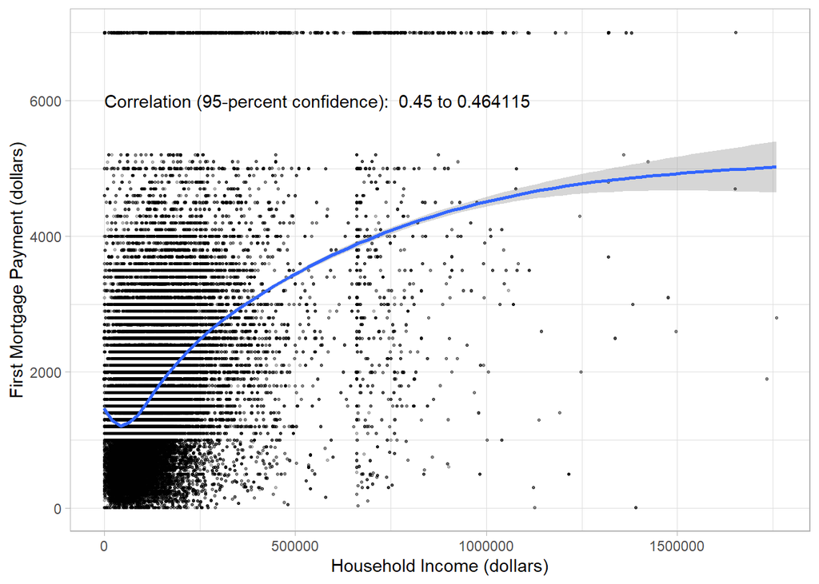

```r
ggplot(household_data_as3,
       aes(x = HINCP, y = MRGP)) +
  geom_point(size = 0.5, alpha = 0.25, position = "jitter") +
  geom_smooth() +
  theme_light() +
  scale_x_continuous(name = "Household Income (dollars)") +
  scale_y_continuous(name = "First Mortgage Payment (dollars)") +
  annotate("text", x = 0, y = 6000,
           label = paste("Correlation (95-percent confidence): ", prettyNum(cor_income_mortgage$conf.int[1], digits =2), "to", prettyNum(cor_income_mortgage$conf.int[2])),
           hjust = 0)
```

The correlation between household income and first mortgage payment is positive and quite strong. With higher income, families tended to spend more on first mortgage payment.

2. Relationship between household income (HINCP) and property value (VALP)

```r
cor_income_property <- cor.test(household_data_as3$HINCP, household_data_as3$VALP)
cor_income_property
```

```
##
##  Pearson's product-moment correlation
##
## data:  household_data_as3$HINCP and household_data_as3$VALP
## t = 139.9, df = 79093, p-value < 2.2e-16
## alternative hypothesis: true correlation is not equal to 0
## 95 percent confidence interval:
##  0.4397766 0.4509500
## sample estimates:
##       cor
## 0.4453807
```

visualizing the relationship

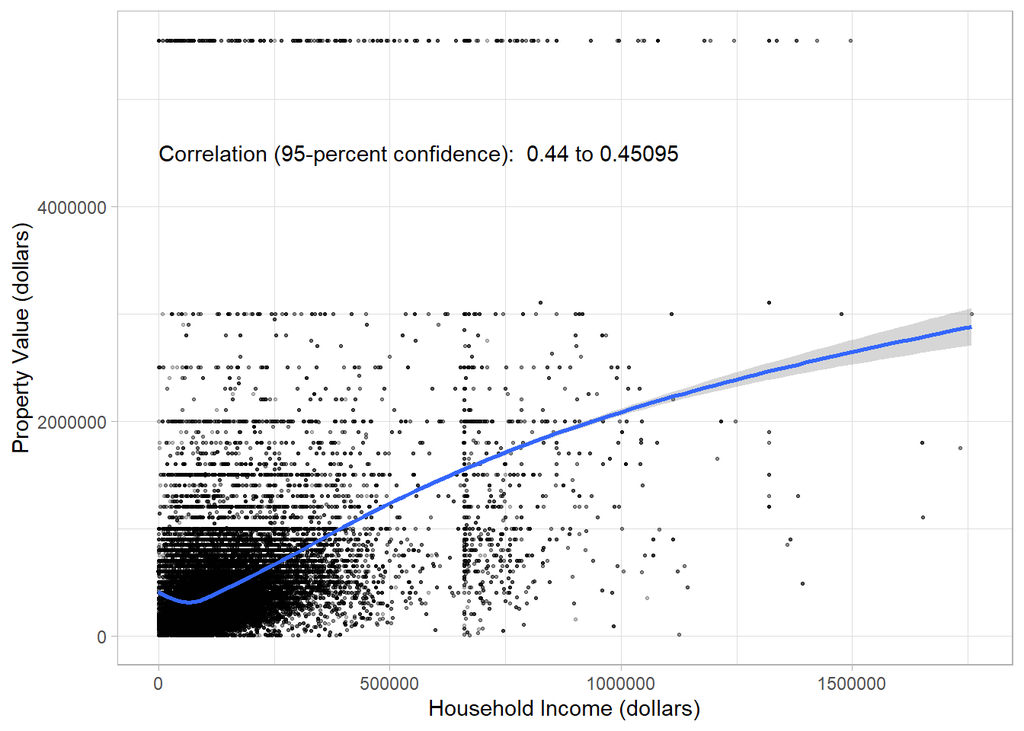

```r
options(scipen = 999)
ggplot(household_data_as3,
       aes(x = HINCP, y = VALP)) +
  geom_point(size = 0.5, alpha = 0.25, position = "jitter") +
  geom_smooth() +
  theme_light() +
  scale_x_continuous(name = "Household Income (dollars)") +
  scale_y_continuous(name = "Property Value (dollars)") +
  annotate("text", x = 0, y = 4500000,
           label = paste("Correlation (95-percent confidence): ", prettyNum(cor_income_property$conf.int[1], digits =2), "to", prettyNum(cor_income_property$conf.int[2])),
           hjust = 0)
```

The correlation between household income and property value is positive and quite strong. Richer families tended to live in more expensive houses.

3. Relationship between first mortgage payment (MRGP) and property value (VALP)

```r
cor_mortgage_property <- cor.test(household_data_as3$MRGP, household_data_as3$VALP)
cor_mortgage_property
```

```
##
##  Pearson's product-moment correlation
##
## data:  household_data_as3$MRGP and household_data_as3$VALP
## t = 185.01, df = 79093, p-value < 0.00000000000000022
## alternative hypothesis: true correlation is not equal to 0
## 95 percent confidence interval:
##  0.5447022 0.5544306
## sample estimates:
##      cor
## 0.549585
```

visualizing the relationship

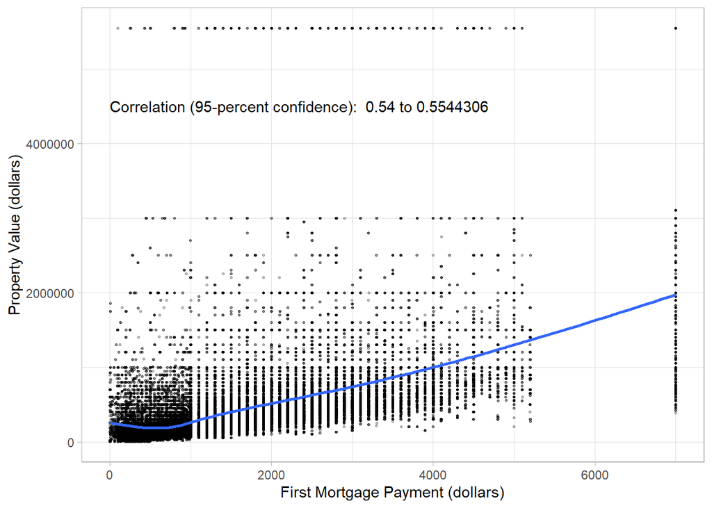

```r
options(scipen = 999)
ggplot(household_data_as3,
       aes(x = MRGP, y = VALP)) +
  geom_point(size = 0.5, alpha = 0.25, position = "jitter") +
  geom_smooth() +
  theme_light() +
  scale_x_continuous(name = "First Mortgage Payment (dollars)") +
  scale_y_continuous(name = "Property Value (dollars)") +
  annotate("text", x = 0, y = 4500000,
           label = paste("Correlation (95-percent confidence): ", prettyNum(cor_mortgage_property$conf.int[1], digits =2), "to", prettyNum(cor_mortgage_property$conf.int[2])),
           hjust = 0)
```

The correlation between the first mortgage payment and property value is positive and quite strong. More expensive houses often require higher first mortgage payments. Yet I am expecting the correlation to be even stronger. I guess that maybe when houses are not that expensive (less than 1000000 dollars), the price has little influence on the first mortgage payment.

# Relationship between a continuous variable and a categorical variable (three or more levels)

I would like to thank Sara for clarification of the Tukey HSD test.

1. Relationship between household income (HINCP) and when structure first built (bd_year)

```r
anova_income_bdage <- aov(HINCP ~ bd_year, data = household_data_as3)
summary(anova_income_bdage)
```

```
##                Df           Sum Sq       Mean Sq F value              Pr(>F)
## bd_year         3    6285852650639 2095284216880   108.8 <0.0000000000000002
## Residuals   79091 1523220027450372   19259081658
##
## bd_year     ***
## Residuals
## ---
## Signif. codes:  0 '***' 0.001 '**' 0.01 '*' 0.05 '.' 0.1 ' ' 1
```

The p-value is much lower than 0.05, so at a 95-percent confidence interval, there is a significant association between the household income and structure age.

Taking a Tukey’s Honestly Significant Difference test to see the magnitude of the differences among the difference categories.

```r
differences_income_bdage <- TukeyHSD(anova_income_bdage)
as_tibble(cbind(pair = row.names(differences_income_bdage$bd_year),
                differences_income_bdage$bd_year))
```

```
## # A tibble: 6 x 5
##   pair             diff          lwr          upr          `p adj`
##   <chr>            <chr>         <chr>        <chr>        <chr>
## 1 Old-New          -30709.39335~ -35659.3392~ -25759.4474~ 0
## 2 Really new-New   3421.5775637~ -6157.71674~ 13000.87187~ 0.795445187676715
## 3 Really old-New   -24517.73746~ -29327.6421~ -19707.8328~ 0
## 4 Really new-Old   34130.970920~ 25410.84241~ 42851.09942~ 0.000000000000045852~
## 5 Really old-Old   6191.6558943~ 3468.983620~ 8914.328167~ 0.000000030864428901~
## 6 Really old-Real~ -27939.31502~ -36580.7188~ -19297.9112~ 0.000000000000043964~
```

Only for the pairing of “Really new” and “New”, the p-value is higher than 0.05, which means that there is little association with the household income.

Visualizing those differences with a box plot

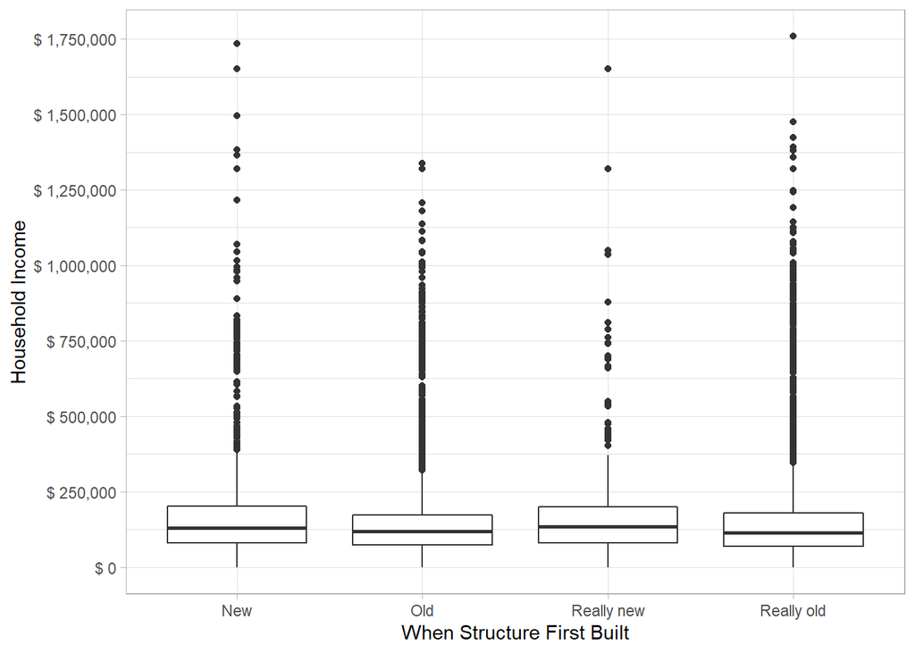

```r
ggplot(household_data_as3,
       aes(x = bd_year, y = HINCP)) +
  geom_boxplot() +
  theme_light() +
#  theme(axis.text.x = element_text(angle = 90)) +
  scale_x_discrete(name = "When Structure First Built") +
  scale_y_continuous(name = "Household Income",
                     breaks = seq(0, 1750000, by = 250000),
                     labels = paste("$",
                                    prettyNum(seq(0, 1750000, by = 250000),
                                              big.mark = ",")))
```

2. Relationship between household income (HINCP) and household language (household_language)

```r
anova_income_language <- aov(HINCP ~ household_language, data = household_data_as3)
summary(anova_income_language)
```

```
##                       Df           Sum Sq       Mean Sq F value
## household_language     4    4938387250701 1234596812675   64.05
## Residuals          79090 1524567492850308   19276362282
##                                 Pr(>F)
## household_language <0.0000000000000002 ***
## Residuals
## ---
## Signif. codes:  0 '***' 0.001 '**' 0.01 '*' 0.05 '.' 0.1 ' ' 1
```

The p-value is much lower than 0.05, so at a 95-percent confidence interval, there is a significant association between the household income and household language.

Taking a Tukey’s Honestly Significant Difference test to see the magnitude of the differences among the difference categories.

```r
differences_income_language <- TukeyHSD(anova_income_language)
as_tibble(cbind(pair = row.names(differences_income_language$household_language),
                differences_income_language$household_language))
```

```
## # A tibble: 10 x 5
##    pair                         diff       lwr        upr        `p adj`
##    <chr>                        <chr>      <chr>      <chr>      <chr>
##  1 English only-Asian and Paci~ -8798.133~ -14706.50~ -2889.763~ 0.000467366510~
##  2 Other Indo-European languag~ 15178.077~ 8157.2901~ 22198.865~ 0.000000036937~
##  3 Other language-Asian and Pa~ 13052.428~ 1082.2197~ 25022.636~ 0.024501199792~
##  4 Spanish-Asian and Pacific I~ -9111.904~ -16450.41~ -1773.390~ 0.006353406189~
##  5 Other Indo-European languag~ 23976.211~ 19581.415~ 28371.006~ 0
##  6 Other language-English only  21850.561~ 11205.907~ 32495.214~ 0.000000214548~
##  7 Spanish-English only         -313.7714~ -5200.135~ 4572.5928~ 0.999789758699~
##  8 Other language-Other Indo-E~ -2125.649~ -13425.70~ 9174.4068~ 0.9860935304947
##  9 Spanish-Other Indo-European~ -24289.98~ -30475.38~ -18104.58~ 0.000000000000~
## 10 Spanish-Other language       -22164.33~ -33664.48~ -10664.17~ 0.000001454525~
```

For the pairing of “other language” and “Other Indo-European languages”, “Spanish” and “English only”, the p-value is higher than 0.05, which means that there is little association with the household income.

Visualizing those differences with a violin plot

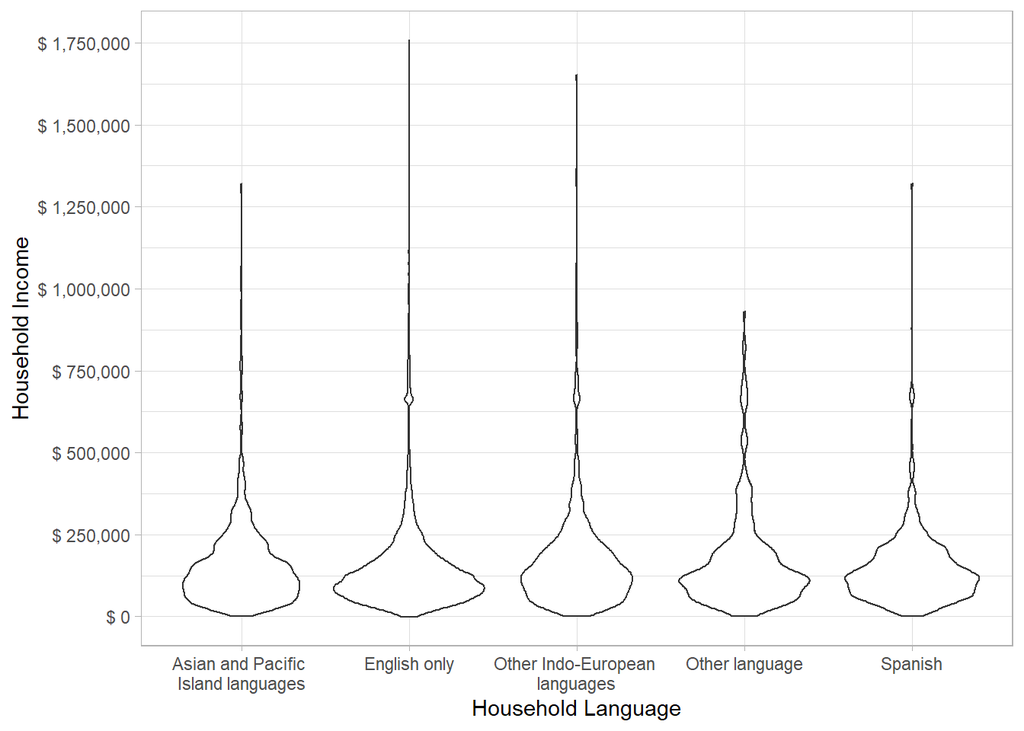

```r
ggplot(household_data_as3,
       aes(x = household_language, y = HINCP)) +
  geom_violin() +
  theme_light() +
  scale_x_discrete(name = "Household Language",
                   labels = c("Asian and Pacific \nIsland languages", "English only", "Other Indo-European \nlanguages", "Other language", "Spanish")) +
  scale_y_continuous(name = "Household Income",
                     breaks = seq(0, 1750000, by = 250000),
                     labels = paste("$",
                                    prettyNum(seq(0, 1750000, by = 250000),
                                              big.mark = ",")))
```

3. Relationship between first mortgage payment (MRGP) and when structure first built (bd_year)

```r
anova_mortgage_bdage <- aov(MRGP~bd_year, data = household_data_as3)
summary(anova_mortgage_bdage)
```

```
##                Df       Sum Sq   Mean Sq F value              Pr(>F)
## bd_year         3    648174638 216058213   124.6 <0.0000000000000002 ***
## Residuals   79091 137135115579   1733890
## ---
## Signif. codes:  0 '***' 0.001 '**' 0.01 '*' 0.05 '.' 0.1 ' ' 1
```

The p-value is much lower than 0.05, so at a 95-percent confidence interval, there is a significant association between the first mortgage payment and structure age.

Taking a Tukey’s Honestly Significant Difference test to see the magnitude of the differences among the difference categories.

```r
differences_mortgage_bdage <- TukeyHSD(anova_income_bdage)
as_tibble(cbind(pair = row.names(differences_mortgage_bdage$bd_year),
                differences_mortgage_bdage$bd_year))
```

[output not shown]

Visualizing those differences with a box plot

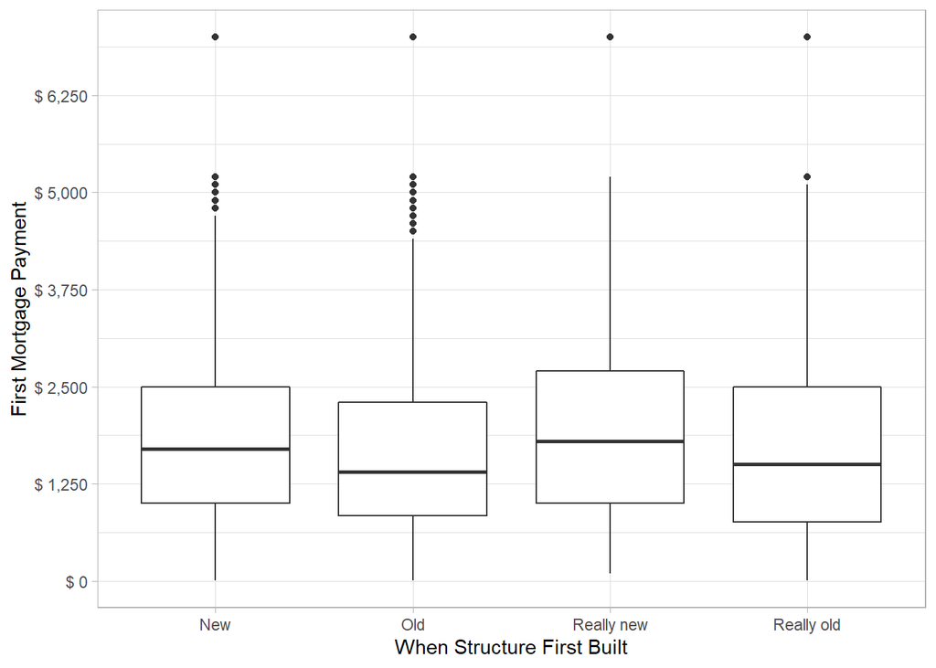

```r
ggplot(household_data_as3,
       aes(x = bd_year, y = MRGP)) +
  geom_boxplot() +
  theme_light() +
  scale_x_discrete(name = "When Structure First Built") +
  scale_y_continuous(name = "First Mortgage Payment",
                     breaks = seq(0, 7500, by = 1250),
                     labels = paste("$",
                                    prettyNum(seq(0, 7500, by = 1250),
                                              big.mark = ",")))
```

4. Relationship between first mortgage payment (MRGP) and household language (household_language)

```r
anova_mortgage_language <- aov(MRGP ~ household_language, data = household_data_as3)
summary(anova_mortgage_language)
```

```
##                       Df       Sum Sq    Mean Sq F value              Pr(>F)
## household_language     4   6842660881 1710665220    1033 <0.0000000000000002
## Residuals          79090 130940629337    1655590
##
## household_language ***
## Residuals
## ---
## Signif. codes:  0 '***' 0.001 '**' 0.01 '*' 0.05 '.' 0.1 ' ' 1
```

The p-value is much lower than 0.05, so at a 95-percent confidence interval, there is a significant association between the first mortgage payment and household language.

Taking a Tukey’s Honestly Significant Difference test to see the magnitude of the differences among the difference categories.

```r
differences_mortgage_language <- TukeyHSD(anova_mortgage_language)
as_tibble(cbind(pair = row.names(differences_mortgage_language$household_language),
                differences_mortgage_language$household_language))
```

```
## # A tibble: 10 x 5
##    pair                         diff       lwr        upr        `p adj`
##    <chr>                        <chr>      <chr>      <chr>      <chr>
##  1 English only-Asian and Paci~ -840.1963~ -894.9522~ -785.4403~ 0
##  2 Other Indo-European languag~ -195.6885~ -260.7538~ -130.6231~ 0.000000000000~
##  3 Other language-Asian and Pa~ -1.683191~ -112.6174~ 109.25104~ 0.999999335731~
##  4 Spanish-Asian and Pacific I~ -351.3702~ -419.3800~ -283.3603~ 0
##  5 Other Indo-European languag~ 644.50778~ 603.77889~ 685.23667~ 0
##  6 Other language-English only  838.51310~ 739.86348~ 937.16273~ 0
##  7 Spanish-English only         488.82609~ 443.54158~ 534.11061~ 0
##  8 Other language-Other Indo-E~ 194.00532~ 89.281737~ 298.72890~ 0.000004308514~
##  9 Spanish-Other Indo-European~ -155.6816~ -213.0050~ -98.35831~ 0.000000000001~
## 10 Spanish-Other language       -349.6870~ -456.2650~ -243.1089~ 0.000000000000~
```

Only for the pairing of “other language” and “Asian and Pacific Island languages”, the p-value is higher than 0.05, which means that there is little association with first mortgage payment.

Visualizing those differences with a violin plot

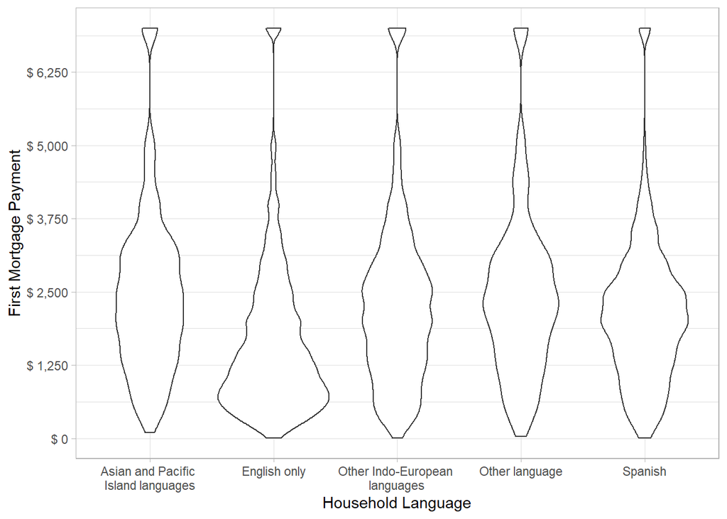

```r
ggplot(household_data_as3,
       aes(x = household_language, y = MRGP)) +
  geom_violin() +
  theme_light() +
  scale_x_discrete(name = "Household Language",
                   labels = c("Asian and Pacific \nIsland languages", "English only", "Other Indo-European \nlanguages", "Other language", "Spanish")) +
  scale_y_continuous(name = "First Mortgage Payment",
                     breaks = seq(0, 7500, by = 1250),
                     labels = paste("$",
                                    prettyNum(seq(0, 7500, by = 1250),
                                              big.mark = ",")))
```

5. Relationship between property value (VALP) and when structure first built (bd_year)

```r
anova_property_bdage <- aov(VALP~bd_year, data = household_data_as3)
summary(anova_property_bdage)
```

```
##                Df            Sum Sq        Mean Sq F value              Pr(>F)
## bd_year         3   234264174731617 78088058243872     221 <0.0000000000000002
## Residuals   79091 27949166531803608   353379860310
##
## bd_year     ***
## Residuals
## ---
## Signif. codes:  0 '***' 0.001 '**' 0.01 '*' 0.05 '.' 0.1 ' ' 1
```

The p-value is much lower than 0.05, so at a 95-percent confidence interval, there is a significant association between the property value and structure age.

Taking a Tukey’s Honestly Significant Difference test to see the magnitude of the differences among the difference categories.

```r
differences_property_bdage <- TukeyHSD(anova_property_bdage)
as_tibble(cbind(pair = row.names(differences_property_bdage$bd_year),
                differences_property_bdage$bd_year))
```

```
## # A tibble: 6 x 5
##   pair             diff          lwr           upr          `p adj`
##   <chr>            <chr>         <chr>         <chr>        <chr>
## 1 Old-New          -128862.6482~ -150065.9532~ -107659.343~ 0
## 2 Really new-New   78249.683686~ 37216.366551~ 119283.0008~ 0.00000573748361143~
## 3 Really old-New   -29019.34727~ -49622.77968~ -8415.91486~ 0.00168664517864681
## 4 Really new-Old   207112.33189~ 169759.28827~ 244465.3755~ 0
## 5 Really old-Old   99843.300929~ 88180.617730~ 111505.9841~ 0
## 6 Really old-Real~ -107269.0309~ -144284.8539~ -70253.2079~ 0.00000000000060851~
```

Visualizing those differences with a box plot

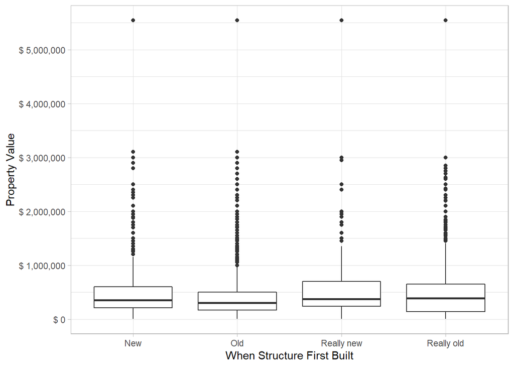

```r
ggplot(household_data_as3,
       aes(x = bd_year, y = VALP)) +
  geom_boxplot() +
  theme_light() +
  scale_x_discrete(name = "When Structure First Built") +
  scale_y_continuous(name = "Property Value",
                     breaks = seq(0, 6000000, by = 1000000),
                     labels = paste("$",
                                    prettyNum(seq(0, 6000000, by = 1000000),
                                              big.mark = ",")))
```

6. Relationship between property value (VALP) and household language (household_language)

```r
anova_property_language <- aov(VALP ~ household_language, data = household_data_as3)
summary(anova_property_language)
```

```
##                       Df            Sum Sq         Mean Sq F value
## household_language     4  1008401279198475 252100319799619   733.7
## Residuals          79090 27175029427336916    343596275475
##                                 Pr(>F)
## household_language <0.0000000000000002 ***
## Residuals
## ---
## Signif. codes:  0 '***' 0.001 '**' 0.01 '*' 0.05 '.' 0.1 ' ' 1
```

The p-value is much lower than 0.05, so at a 95-percent confidence interval, there is a significant association between the property value and household language.

Taking a Tukey’s Honestly Significant Difference test to see the magnitude of the differences among the difference categories.

```r
differences_property_language <- TukeyHSD(anova_property_language)
as_tibble(cbind(pair = row.names(differences_property_language$household_language),
                differences_property_language$household_language))
```

```
## # A tibble: 10 x 5
##    pair                          diff       lwr        upr       `p adj`
##    <chr>                         <chr>      <chr>      <chr>     <chr>
##  1 English only-Asian and Pacif~ -340436.2~ -365380.9~ -315491.~ 0
##  2 Other Indo-European language~ -78723.14~ -108364.4~ -49081.8~ 0.000000000004~
##  3 Other language-Asian and Pac~ -16768.36~ -67305.82~ 33769.09~ 0.895071374783~
##  4 Spanish-Asian and Pacific Is~ -232841.5~ -263824.3~ -201858.~ 0
##  5 Other Indo-European language~ 261713.05~ 243158.51~ 280267.6~ 0
##  6 Other language-English only   323667.84~ 278726.79~ 368608.8~ 0
##  7 Spanish-English only          107594.62~ 86964.702~ 128224.5~ 0
##  8 Other language-Other Indo-Eu~ 61954.785~ 14246.665~ 109662.9~ 0.003638200462~
##  9 Spanish-Other Indo-European ~ -154118.4~ -180232.8~ -128004.~ 0
## 10 Spanish-Other language        -216073.2~ -264626.1~ -167520.~ 0
```

Only for the pairing of “other language” and “Asian and Pacific Island languages”, the p-value is higher than 0.05, which means that there is little association with the property value.

Visualizing those differences with a violin plot

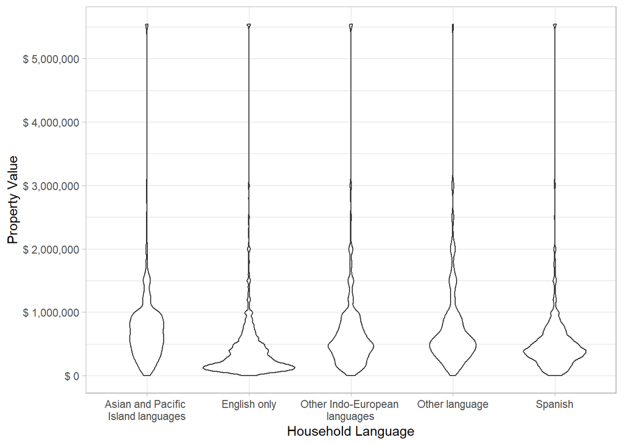

```r
ggplot(household_data_as3,
       aes(x = household_language, y = VALP)) +
  geom_violin() +
  theme_light() +
  scale_x_discrete(name = "Household Language",
                   labels = c("Asian and Pacific \nIsland languages", "English only", "Other Indo-European \nlanguages", "Other language", "Spanish")) +
  scale_y_continuous(name = "Property Value",
                     breaks = seq(0, 6000000, by = 1000000),
                     labels = paste("$",
                                    prettyNum(seq(0, 6000000, by = 1000000),
                                              big.mark = ",")))
```

# Relationship between two categorical variables

Relationship between when structure first built (bd_year) and household language (household_language)

```r
chi_bdage_language <- chisq.test(household_data_as3$bd_year, household_data_as3$household_language)
chi_bdage_language
```

```
##
##  Pearson's Chi-squared test
##
## data:  household_data_as3$bd_year and household_data_as3$household_language
## X-squared = 400.89, df = 12, p-value < 0.00000000000000022
```

The p-value is much less than 0.05, so the relationship is significant at a 95-percent confidence level.

Here are the values I observe for combination of variables:

```r
observation <- chi_bdage_language$observed
observation
```

```
##
## household_data_as3$bd_year Asian and Pacific Island languages English only
##                 New                                       367         4630
##                 Old                                      1371        22259
##                 Really new                                 89         1311
##                 Really old                               2594        29968
##
## household_data_as3$bd_year Other Indo-European languages Other language Spanish
##                 New                                  745            128     450
##                 Old                                 2764            399    2162
##                 Really new                           279             18      77
##                 Really old                          4725            749    4010
```

Here are the values I would expect if the two variables were not related:

```r
expectation <- chi_bdage_language$expected
expectation
```

```
##
## household_data_as3$bd_year Asian and Pacific Island languages English only
##                 New                                 353.25520     4647.851
##                 Old                                1618.43422    21294.070
##                 Really new                           99.15739     1304.634
##                 Really old                         2350.15318    30921.445
##
## household_data_as3$bd_year Other Indo-European languages Other language
##                 New                             680.2220      103.39566
##                 Old                            3116.4285      473.70592
##                 Really new                      190.9357       29.02277
##                 Really old                     4525.4137      687.87564
##
## household_data_as3$bd_year   Spanish
##                 New         535.2763
##                 Old        2452.3617
##                 Really new  150.2500
##                 Really old 3561.1120
```

Visualizing the differences between observation and expectation with a hear map. I learned this visualisation idea from Ryan.

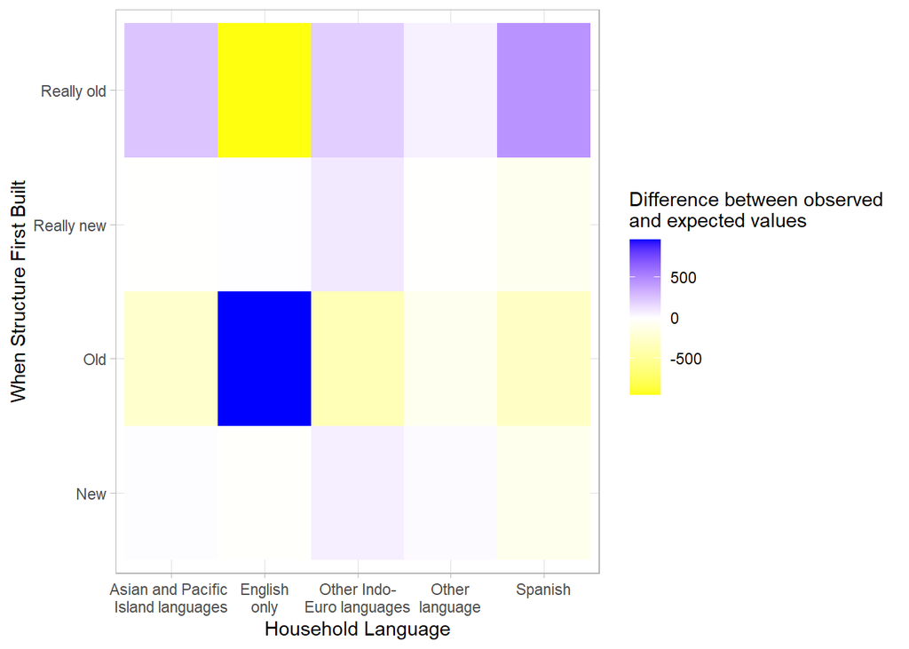

```r
differences <- observation - expectation
difference_obs_exp <- as.data.frame(differences)
ggplot(difference_obs_exp,
       aes(x = Var2, y = household_data_as3.bd_year, fill = Freq)) +
  geom_tile() +
  scale_x_discrete(name = "Household Language",
                   labels = c("Asian and Pacific \nIsland languages", "English\nonly", "Other Indo-\nEuro languages", "Other\nlanguage", "Spanish")) +
  scale_y_discrete(name = "When Structure First Built") +
  scale_fill_gradient2(name = "Difference between observed \nand expected values",
                       low="yellow",
                       high="blue") +
  theme_light()
```